# DSC 595 (001) - Intro to R and Rstudio (Posit)

Lecture 7 - Graphing with ggplot()

Spring 2024

# Lecture 7: Graphics with ggplot2

### Learning Outcomes

- Learn Basic Plots using ggplot2 package
- Understand ggplot2’s syntax for building up a plot from a blank canvas
  - Aesthetics
  - Geometries

# Tidyverse and ggplot2

- ggplot2 is part of the tidyverse
  - it gets loaded with library(tidyverse)
  - or you can load it with just library(ggplot2)
- Resource - grammar of graphics in ggplot2 (https://r4ds.hadley.nz/layers)
- **Aesthetics of graphics objects**
  - What variables on represented by X or Y axes?
  - What variables are represented by a color?
  - What variable is represented by the size?
  - What variable is represented by the shape of the point?
- **Geometry of the graphics object**

# We’ll use the built-in airquality dataset to illustrate

```
-   ?airquality for information
-   Daily air quality measurements in New York, May to September 1973
```

```r
airquality %>% head %>%
  kbl(caption = "First 6 records of the airquality Dataset in R") %>%
  kable_classic_2(full_width = F)
```

First 6 records of the airquality Dataset in R

| Ozone | Solar.R | Wind | Temp | Month | Day |
| --- | --- | --- | --- | --- | --- |
| 41 | 190 | 7.4 | 67 | 5 | 1 |
| 36 | 118 | 8.0 | 72 | 5 | 2 |
| 12 | 149 | 12.6 | 74 | 5 | 3 |
| 18 | 313 | 11.5 | 62 | 5 | 4 |
| NA | NA | 14.3 | 56 | 5 | 5 |
| 28 | NA | 14.9 | 66 | 5 | 6 |

```r
print("Structure of the airquality dataset in R")
```

```
[1] "Structure of the airquality dataset in R"
```

```r
str(airquality)
```

```
'data.frame':   153 obs. of  6 variables:
 $ Ozone  : int  41 36 12 18 NA 28 23 19 8 NA ...
 $ Solar.R: int  190 118 149 313 NA NA 299 99 19 194 ...
 $ Wind   : num  7.4 8 12.6 11.5 14.3 14.9 8.6 13.8 20.1 8.6 ...
 $ Temp   : int  67 72 74 62 56 66 65 59 61 69 ...
 $ Month  : int  5 5 5 5 5 5 5 5 5 5 ...
 $ Day    : int  1 2 3 4 5 6 7 8 9 10 ...
```

# Graphics! - Scatterplots

### Used to examine the relationship between two (usually numeric) variables

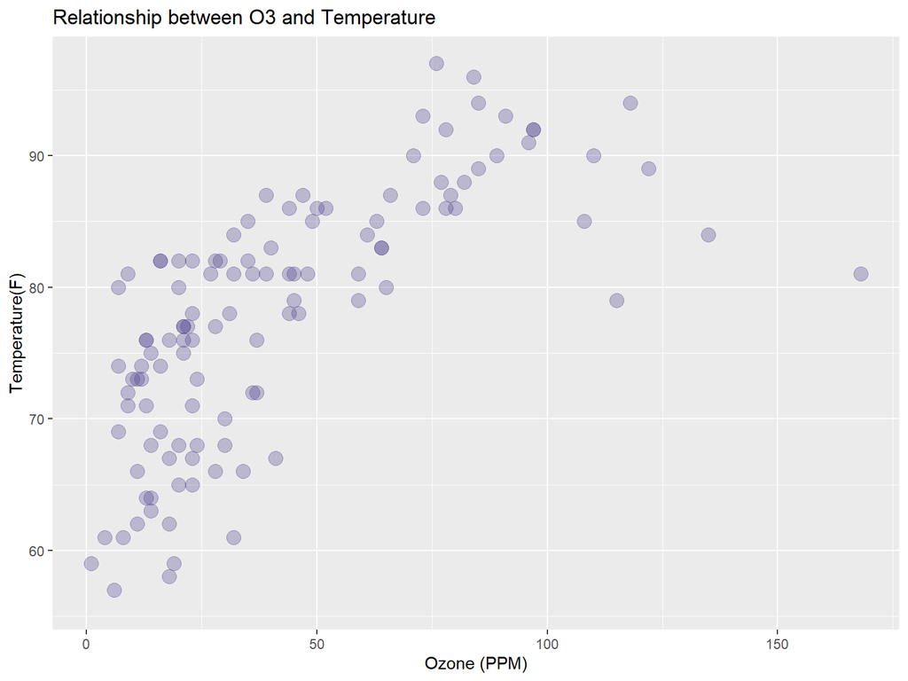

```r
airquality %>%
  ggplot( ., aes(x = Ozone, y = Temp)) + ## Set up the aesthetics
  geom_point(color = "slateblue4", size = 4, alpha = .3) + ## Specify a point plot
  ggtitle("Relationship between O3 and Temperature") + ## Add in descriptive title for our graph
  xlab("Ozone (PPM)") + ## Add in descriptive label for our axis
  ylab("Temperature(F)") ## Add in descriptive label for our axis
```

### Things to notice

- we used the pipe into ggplot() and explicitly told ggplot2 that the data to use was what was passed by the pipe
  - we did this with the period (.)
- aes() was used to define the underlying structure of the plot
- we then layered on what ggplot2 refers to as a “geometry” -> in this case **geom_point**
- we specifed the size and the translucence of the points with the **size** and **alpha** parameters
- The warning -> refers to where one of the values on the dataset was missing for either the x or y or both

# Scatterplot - Color by Month

```
Warning: Removed 37 rows containing missing values (`geom_point()`).
```

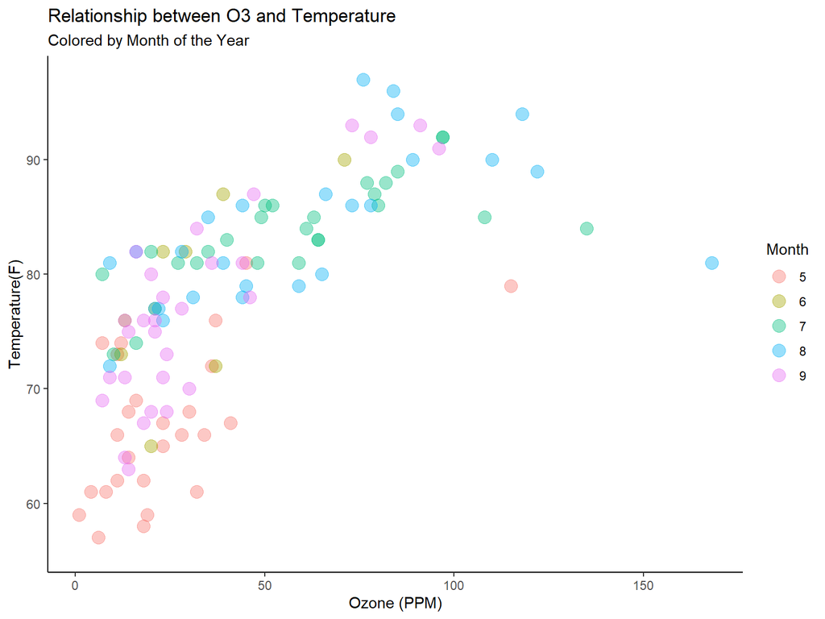

```r
airquality %>%
  mutate(Month = as.factor(Month)) %>% ## Change Month to a Categorical variable
  ggplot( ., aes(x = Ozone, y = Temp, color = Month)) + ## addin color aesthetic
  geom_point(size = 4, alpha = .4) +  ## these are actually additional aesthetics added to the geom_point() layer
    ggtitle(label = "Relationship between O3 and Temperature", subtitle = "Colored by Month of the Year") +
  xlab("Ozone (PPM)") +
  ylab("Temperature(F)") +
  theme_classic() ## use different theme to change plot appearance
```

# Scatterplot - Symbol by month (shape)

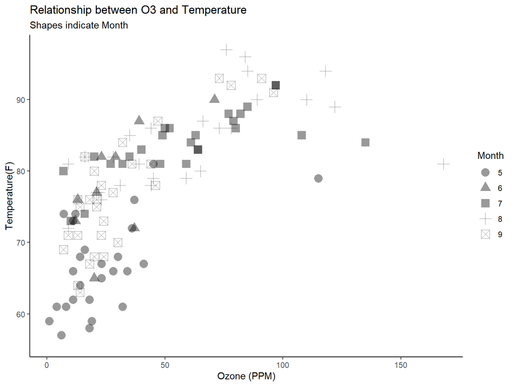

```r
airquality %>%
  mutate(Month = as.factor(Month)) %>% ## Change Month to a Categorical variable
  ggplot( ., aes(x = Ozone, y = Temp, shape = Month)) +
  geom_point(size = 4, alpha = .4) +
    ggtitle(label = "Relationship between O3 and Temperature", subtitle = "Shapes indicate Month"
              ) +
  xlab("Ozone (PPM)") +
  ylab("Temperature(F)") +
  theme_classic() ## use different theme to change plot appearance
```

# Scatterplot - Size by Solar Radiation

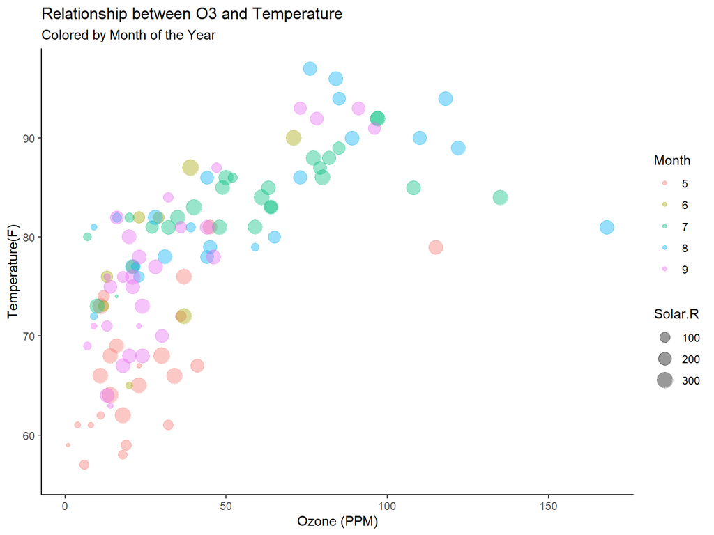

```r
airquality %>%
  mutate(Month = as.factor(Month)) %>% ## Change Month to a Categorical variable
  ggplot( ., aes(x = Ozone, y = Temp, size = Solar.R, color = Month)) +
  geom_point(alpha = .4) +
    ggtitle(label = "Relationship between O3 and Temperature", subtitle = "Colored by Month of the Year"
              ) +
  xlab("Ozone (PPM)") +
  ylab("Temperature(F)") +
  theme_classic() ## use different theme to change plot appearance
```

### These were all changing of aesthetics for the same geometry

# Adding lines through X,Y numerical data with the **geom_smooth()** geometry

### geom_smooth() is a geometry used for drawing lines through the data

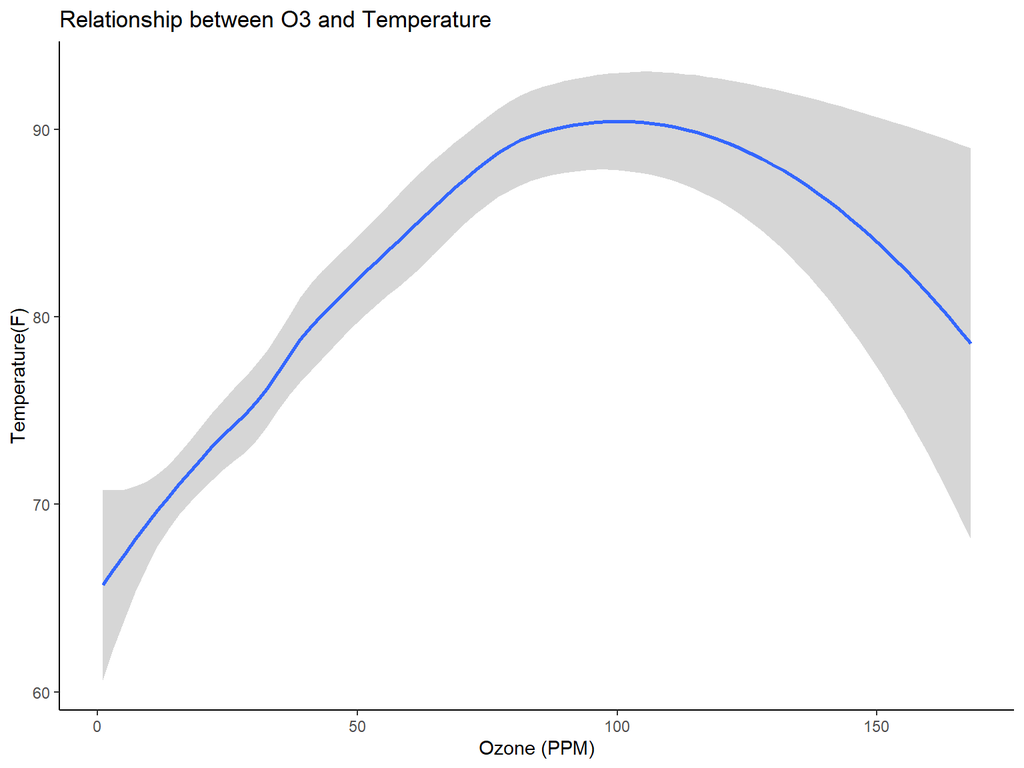

```r
airquality %>%
  ggplot( ., aes(x = Ozone, y = Temp)) +
  geom_smooth() +
  ggtitle(label = "Relationship between O3 and Temperature") +
  xlab("Ozone (PPM)") +
  ylab("Temperature(F)") +
  theme_classic() ## use different theme to change plot appearance
```

### Notice that we don’t have the points, just a line through the points

# Layering geometries

- geom_point() to add points
- geom_smooth() to add the fit through the points

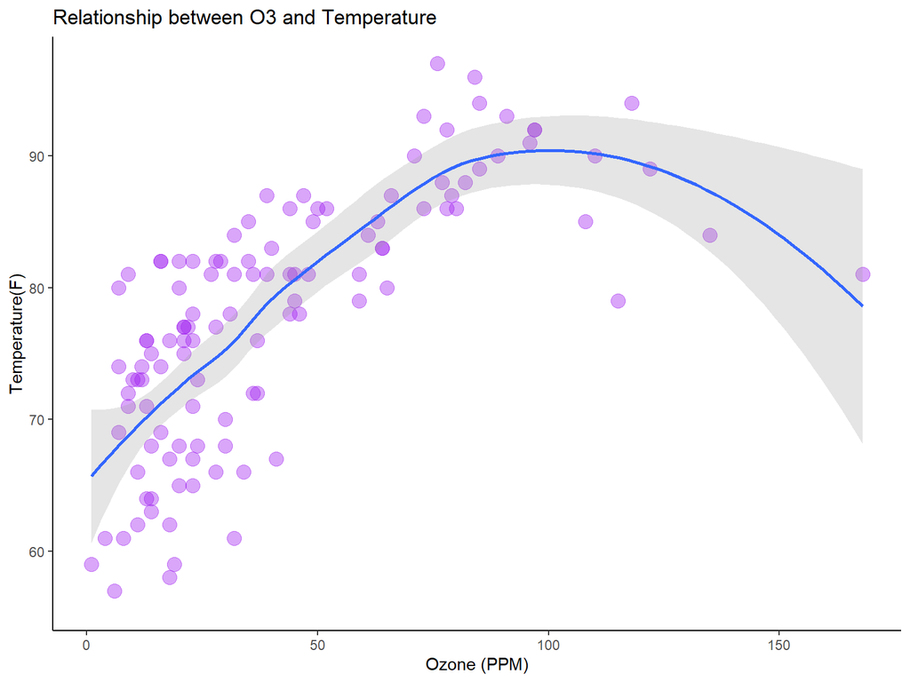

```r
airquality %>%
  # mutate(Month = as.factor(Month)) %>% ## Change Month to a Categorical variable
  ggplot( ., aes(x = Ozone, y = Temp)) +
  geom_point(size = 4, alpha = .4, color = "purple") +
  geom_smooth(alpha = .25) + ## lighten the shading of the standard error shading
  ggtitle(label = "Relationship between O3 and Temperature") +
  xlab("Ozone (PPM)") +
  ylab("Temperature(F)") +
  theme_classic() ## use different theme to change plot appearance
```

# Doing the smoothing by month

- Smooth
- Overlay the points on top

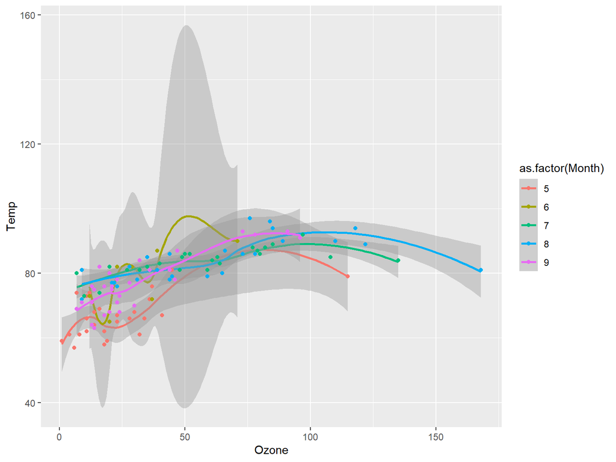

```r
airquality %>%
  ggplot( ., aes(x = Ozone, y = Temp, color = as.factor(Month))) +
  geom_smooth() +
  geom_point()
```

- This one has default settings
  - loess fit not linear
  - no real formatting
  - missing title and labels

# Doing the smoothing by month and using a linear fit!

- Smooth with linear fit
- Overlay the points on top

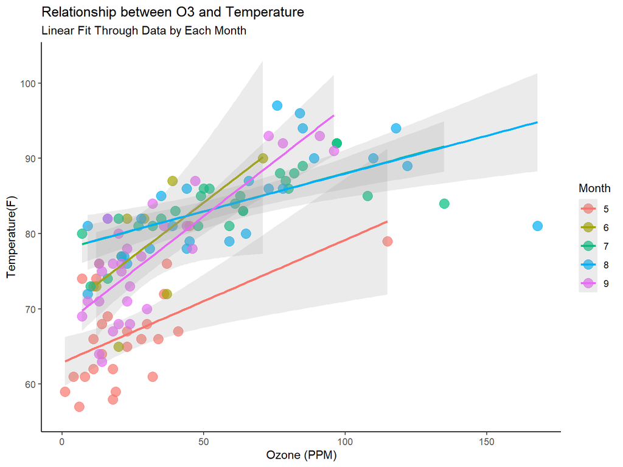

```r
airquality %>%
  mutate(Month = as.factor(Month)) %>% ## Change Month to a Categorical variable
  ggplot( ., aes(x = Ozone, y = Temp, color = Month)) + ##
  geom_point(size = 4, alpha = .7) +
  geom_smooth(method = lm, se = T, alpha = .2) + ## turn off error bars around the fit to see better
  ggtitle(label = "Relationship between O3 and Temperature",
          subtitle = "Linear Fit Through Data by Each Month") +
  xlab("Ozone (PPM)") +
  ylab("Temperature(F)") +
  theme_classic() ## use different theme to change plot appearance
```

# Geometries and Subsetting

- using the geom_point() geometry we will lay down all points
- overwrite that geometry for a subset and change the aesthetics!
  - both for points and for the smooth geometries

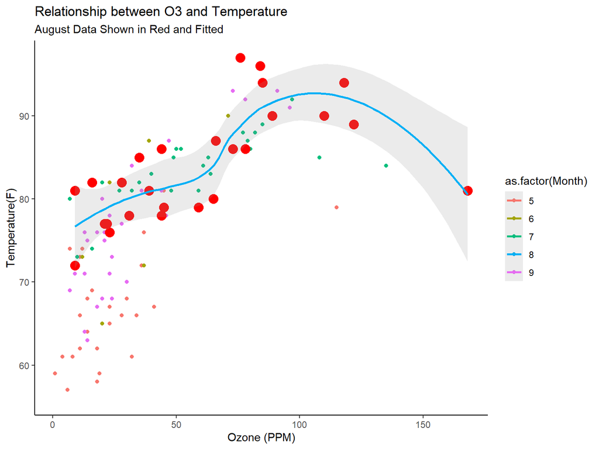

```r
airquality %>%
  ggplot( ., aes(x = Ozone, y = Temp, color = as.factor(Month))) +
  geom_point() + ## This layer uses all data in these two fields
  geom_point(
    data = airquality %>%  filter(Month == 8),  ## For this layer, we pass the same dataset and filter it on the fly!
    color = "red", size = 4, shape = 16) + ## And specify different formatting parameters
  geom_smooth(data = airquality %>% filter(Month == 8), alpha = .2) +  ## similarly for we pass geom_smooth() a subset of the data
  ggtitle(label = "Relationship between O3 and Temperature",
          subtitle = "August Data Shown in Red and Fitted") +
  xlab("Ozone (PPM)") +
  ylab("Temperature(F)") +
  theme_classic()
```

# Barplots and GWAS Dataset

##### We’ll load the GWAS dataset and do some munging prior to graphing

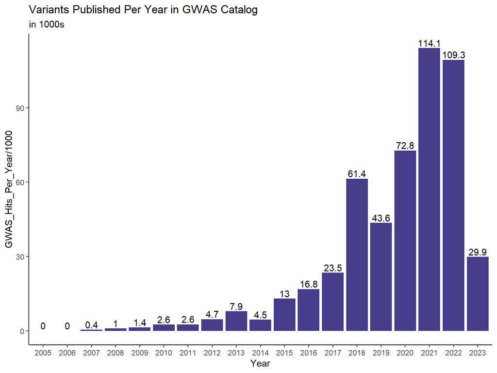

```r
load("gwas.RData")

gwas %>%
  dplyr::filter(CHR_ID %in% as.character(1:22)) %>% ## keep only CHR in 1:22
  mutate(CHR = as.numeric(CHR_ID)) %>% ## create a factor variable for our chromosomes
  mutate(Year  = as.factor(year(DATE))) %>% ## Create year from the Date field
  group_by(Year) %>% ## group by Year
  summarise(GWAS_Hits_Per_Year = n()) %>% ## Calculate rows of the dataset by year for these 1:22 Chromosomes
  ggplot(data = ., aes(x = Year, y = GWAS_Hits_Per_Year/1000)) +  ## Create bar chart of the findings by year
  geom_bar(position = "stack", stat = "identity", fill = "slateblue4") +
  ggtitle(label = "Variants Published Per Year in GWAS Catalog",subtitle = "in 1000s") +
  geom_text(aes(label=round(GWAS_Hits_Per_Year/1000,1)), position=position_dodge(width=0.9), vjust=-0.25) +
  theme_classic()
```

### Note: We are able to do some calculations within ggplot syntax as seen by dividing the entries/year by 1000 in the aes() and geom_text() statements

# using a function `cumsum()` to specify a special kind of aesthetic

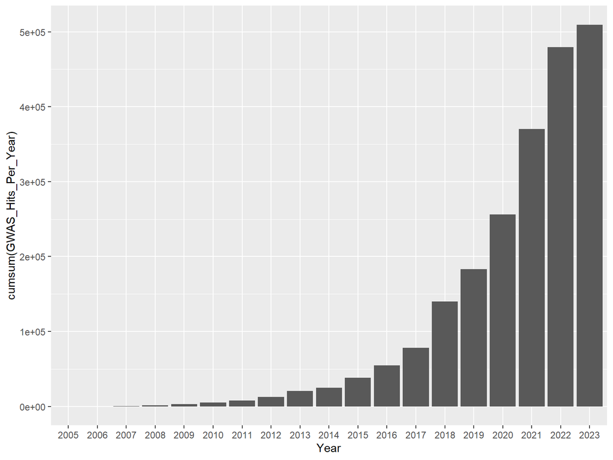

```r
gwas %>%
  dplyr::filter(CHR_ID %in% as.character(1:22)) %>% ## keep only CHR in 1:22
  mutate(Year  = as.factor(year(DATE))) %>% ## Create year from the Date field
  group_by(Year) %>% ## group by Year and Chromosome
  summarise(GWAS_Hits_Per_Year = n()) %>%
  ggplot(data = ., aes(x = Year, y = cumsum(GWAS_Hits_Per_Year))) +  ## Create cumulative summed bar chart through time
    geom_bar(position = "stack", stat = "identity")  ## Stat = identity means use the data given to
```

# Is the Month that papers are puplished more likely to be end of year?

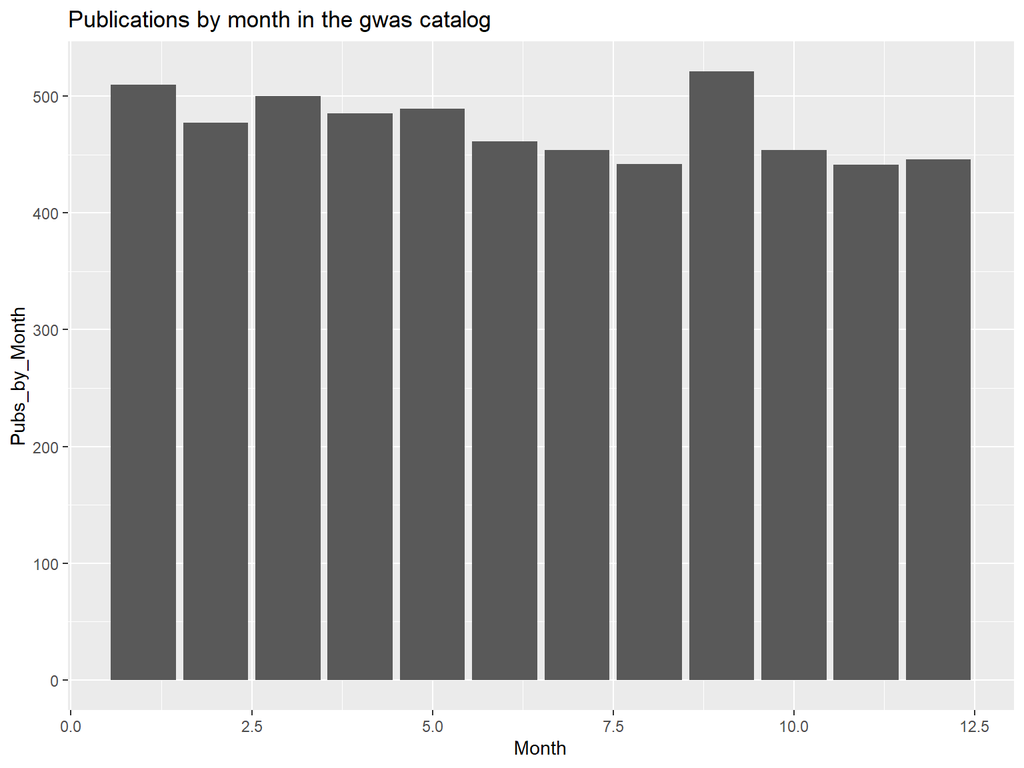

```r
gwas %>%
  dplyr::filter(CHR_ID %in% as.character(1:22)) %>% ## keep only CHR in 1:22
  mutate(CHR = as.numeric(CHR_ID)) %>% ## create a factor variable for our chromosomes
  mutate(Month  = month(DATE)) %>% ## Create year from the Date field
  group_by(Month) %>% ## group by Month
  summarise(Pubs_by_Month = n_distinct(PUBMEDID)) %>%
  ggplot(data = ., aes(x = Month, y = Pubs_by_Month)) +  ## Create cumulative summed bar chart through time
    geom_bar(position = "stack", stat = "identity")  +
  ggtitle("Publications by month in the gwas catalog")
```

# These were the tinyest subset of possible graph types!

- We wanted to cover how ggplot2 specifies a plot, and builds up the layers with geometries
- We will cover some more plot types and visualizations in the second ggplot2 lecture
- In that lecture we will also cover formatting of axes labels, plot titles and multiple plots on the same page

#### Excellent resource for all kinds of plot types with the ggplot2 package: https://r-graph-gallery.com/ggplot2-package.html

#### Excellent resource for ALL KINDS of plots with and without ggplot2 - https://r-graph-gallery.com/

# Bonus - GIS example map

#### From here: https://www.paulamoraga.com/book-spatial/making-maps-with-r.html

```r
# install.packages("sf")
# install.packages("viridis")
library(sf)
nameshp <- system.file("shape/nc.shp", package = "sf")
d <- st_read(nameshp, quiet = TRUE)
d$vble <- d$SID74
d$vble2 <- d$SID79

library(viridis)
```

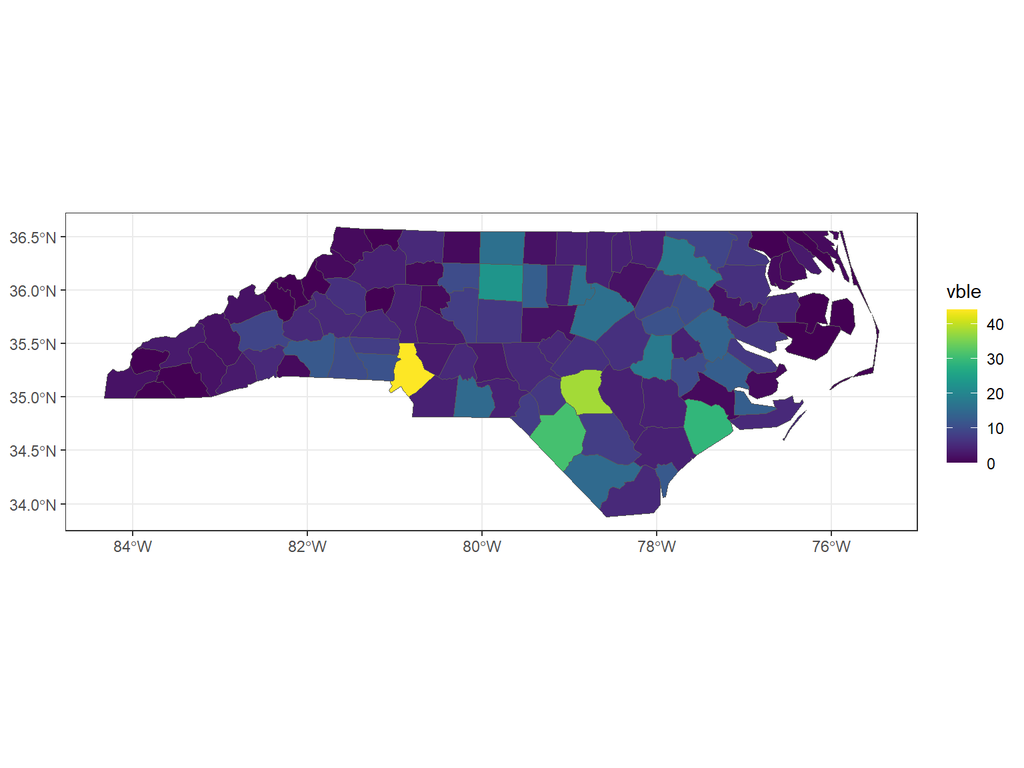

```r
ggplot(d) + geom_sf(aes(fill = vble)) +
  scale_fill_viridis() + theme_bw()
```

# Zoomable widget in the HTML!

```r
# install.packages("leaflet")
library(leaflet)
pal <- colorNumeric(palette = "YlOrRd", domain = d$vble)
l <- leaflet(d) %>% addTiles() %>%
  addPolygons(color = "white", fillColor = ~ pal(vble),
              fillOpacity = 0.8) %>%
  addLegend(pal = pal, values = ~vble, opacity = 0.8)
l
```

[interactive chart not shown]